# Course Notes 3

January 12, 2016

## `chicagoNMMAPS` data

## `chicagoNMMAPS` data

For the examples in this lecture, I'll use some data from Chicago on mortality, temperature, and air pollution. These data are available as part of the `dlnm` package. You can load them in R using the following code:

```r
library(dlnm)
data("chicagoNMMAPS")
```

## `chicagoNMMAPS` data

To make the data a little easier to use, I'll rename the data frame as `chic`:

```r
chic <- chicagoNMMAPS
chic[1:3, c("date", "death", "cvd", "temp", "dptp", "pm10", "o3")]
```

```
##         date death cvd       temp   dptp     pm10       o3
## 1 1987-01-01   130  65 -0.2777778 31.500 26.95607 4.376079
## 2 1987-01-02   150  73  0.5555556 29.875       NA 4.929803
## 3 1987-01-03   101  43  0.5555556 27.375 32.83869 3.751079
```

## `chicagoNMMAPS` data

To find out more about this data, you can look at its help file:

```r
?chicagoNMMAPS
```

## Simple statistics to explore data

## Simple statistics functions

Here are some simple statistics functions you will likely use often:

| Function | Description |
| --- | --- |
| `range()` | Range (minimum and maximum) of vector |
| `min()`, `max()` | Minimum or maximum of vector |
| `mean()`, `median()` | Mean or median of vector |
| `table()` | Number of observations per level for a factor vector |
| `cor()` | Determine correlation(s) between two or more vectors |
| `summary()` | Summary statistics, depends on class |

## Simple statistic examples

All of these take, as the main argument, the vector(s) for which you want the statistic. If there are missing values in the vector, you'll need to add an option to say what to do when them (e.g., `na.rm` or `use="complete.obs"`).

```r
mean(chic$pm10, na.rm = TRUE)
```

```
## [1] 33.74186
```

```r
range(chic$pm10, na.rm = TRUE)
```

```
## [1]  -3.049835 356.176754
```

```r
table(chic$dow)
```

```
##
##    Sunday    Monday   Tuesday Wednesday  Thursday    Friday  Saturday
##       731       730       730       730       731       731       731
```

## Simple statistic examples

The `cor` function can take two or more vectors. If you give it multiple values, it will give the correlation matrix for all the vectors.

```r
cor(chic$temp, chic$o3, use = "complete.obs")
```

```
## [1] 0.5676444
```

```r
cor(chic[ , c("temp", "dptp", "o3")], use = "complete.obs")
```

```
##           temp      dptp        o3
## temp 1.0000000 0.9477388 0.5676444
## dptp 0.9477388 1.0000000 0.4549373
## o3   0.5676444 0.4549373 1.0000000
```

## `summary()`: A bit of OOP

R supports object-oriented programming. This shows up with `summary()`. R looks to see what type of object it's dealing with, and then uses a method specific to that object type.

```r
class(chic$temp)
```

```
## [1] "numeric"
```

```r
summary(chic$temp)
```

```
##    Min. 1st Qu.  Median    Mean 3rd Qu.    Max.
## -26.670   1.667  10.560  10.110  19.440  33.330
```

## `summary()`: A bit of OOP

R supports object-oriented programming. This shows up with `summary()`. R looks to see what type of object it's dealing with, and then uses a method specific to that object type.

```r
class(chic$dow)
```

```
## [1] "factor"
```

```r
summary(chic$dow)
```

```
##    Sunday    Monday   Tuesday Wednesday  Thursday    Friday  Saturday
##       731       730       730       730       731       731       731
```

We'll see more of this when we do regression models.

## Using regression models to explore data

## Formula structure

In R, formulas take this structure:

```r
[response variable] ~ [indep. var. 1] +  [indep. var. 2] + ...
```

Notice that `~` used to separate the independent and dependent variables and the `+` used to join independent variables.

You will use this type of structure in a lot of different function calls, including those for linear models (`lm`) and generalized linear models (`glm`).

## Linear models

To fit a linear model, you can use the function `lm()`. Use the `data` option to specify the dataframe from which to get the vectors. You can save the model as an object.

```r
mod_a <- lm(dptp ~ temp, data = chic)
```

This call fits the model:

\[ Y_{i} = \beta_{0} + \beta_{1}X_{1,i} + \epsilon_{i} \]

where:

- \(Y_{i}\) : dew point temperature on day \(i\)
- \(X_{1,i}\) : temperature on day \(i\)

## Using model objects

Some functions you can use on model objects:

| Function | Description |
| --- | --- |
| `summary()` | Get a variety of information on the model, including coefficients and p-values for the coefficients |
| `coef()` | Pull out just the coefficients for a model |
| `residuals()` | Get the model residuals |
| `fitted()` | Get the fitted values from the model (for the data used to fit the model) |
| `plot()` | Create plots to help assess model assumptions |
| `abline()` | Add a regression line to a scatterplot based on the model |

## Examples of using a model object

For example, you can get the coefficients from the model we just fit:

```r
coef(mod_a)
```

```
## (Intercept)        temp
##    24.02487     1.62065
```

You can also pull out the residuals:

```r
head(residuals(mod_a))
```

```
##        1        2        3        4        5        6
## 7.925312 4.949770 2.449770 7.301214 4.850131 3.897243
```

## Examples of using a model object

You can also plot the data you used to fit the model and add a regression based on the model fit, using `geom_abline()`:

```r
chic_plot <- ggplot(chic, aes(x = temp, y = dptp)) +
        geom_point(alpha = 0.2) +
        xlab("Temperature (C)") + ylab("Dew Point (F)")
chic_plot + geom_abline(intercept = coef(mod_a)[1],
                        slope = coef(mod_a)[2], color = "red")
```

(see next page)

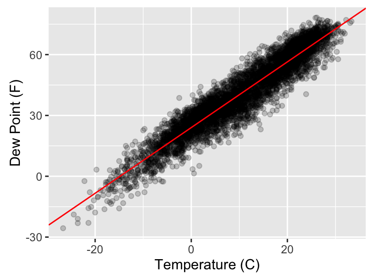

## Examples of using a model object

The `summary()` function gives you a lot of information about the model:

```r
summary(mod_a)
```

(see next slide)

```
##
## Call:
## lm(formula = dptp ~ temp, data = chic)
##
## Residuals:
##      Min       1Q   Median       3Q      Max
## -24.3093  -3.7470   0.4687   4.0738  18.6518
##
## Coefficients:
##              Estimate Std. Error t value Pr(>|t|)
## (Intercept) 24.024869   0.112933   212.7   <2e-16 ***
## temp         1.620650   0.007631   212.4   <2e-16 ***
## ---
## Signif. codes:  0 '***' 0.001 '**' 0.01 '*' 0.05 '.' 0.1 ' ' 1
##
## Residual standard error: 5.899 on 5112 degrees of freedom
## Multiple R-squared:  0.8982, Adjusted R-squared:  0.8982
## F-statistic: 4.511e+04 on 1 and 5112 DF,  p-value: < 2.2e-16
```

## `summary` for `lm` objects

The object created when you use the `summary()` function on an `lm` object has several different parts you can pull out using the `$` operator:

```r
names(summary(mod_a))
```

```
##  [1] "call"          "terms"         "residuals"     "coefficients"
##  [5] "aliased"       "sigma"         "df"            "r.squared"
##  [9] "adj.r.squared" "fstatistic"    "cov.unscaled"
```

```r
summary(mod_a)$coefficients
```

```
##             Estimate  Std. Error  t value Pr(>|t|)
## (Intercept) 24.02487 0.112933468 212.7347        0
## temp         1.62065 0.007630629 212.3875        0
```

## Fitting a model with a factor

You can also use binary variables or factors as independent variables in regression models:

```r
mod_b <- lm(pm10 ~ dow, data = chic)
summary(mod_b)$coefficients
```

```
##               Estimate Std. Error   t value      Pr(>|t|)
## (Intercept)  27.521671  0.7303211 37.684344 7.467602e-273
## dowMonday     6.132236  1.0339702  5.930767  3.224025e-09
## dowTuesday    6.795433  1.0268941  6.617462  4.048930e-11
## dowWednesday  8.476816  1.0261689  8.260644  1.850086e-16
## dowThursday   8.804654  1.0240148  8.598171  1.078208e-17
## dowFriday     9.481589  1.0261689  9.239794  3.609870e-20
## dowSaturday   3.660201  1.0268941  3.564342  3.682785e-04
```

## Fitting a model with a factor

This call fits the model:

\[ Y_{i} = \beta_{0} + \beta_{1}X_{1,i} + \epsilon_{i} \]

where \(X_{1,i}\) : day of the week of day \(i\)

## Linear models versus GLMs

You can fit a variety of models, including linear models, logistic models, and Poisson models, using generalized linear models (GLMs).

For linear models, the only difference between `lm` and `glm` is how they're fitting the model (least squares versus maximum likelihood). You should get the same results regardless of which you pick.

## Linear models versus GLMs

For example:

```r
mod_c <- glm(dptp ~ temp, data = chic)
summary(mod_c)$coef
```

```
##             Estimate  Std. Error  t value Pr(>|t|)
## (Intercept) 24.02487 0.112933468 212.7347        0
## temp         1.62065 0.007630629 212.3875        0
```

```r
summary(mod_a)$coef
```

```
##             Estimate  Std. Error  t value Pr(>|t|)
## (Intercept) 24.02487 0.112933468 212.7347        0
## temp         1.62065 0.007630629 212.3875        0
```

## GLMs

You can fit other model types with `glm()` using the `family` option:

| Model type | `family` option |
| --- | --- |
| Linear | `family = gaussian(link = "identity")` (or use model defaults) |
| Logistic | `family = binomial(link = "logit")` |
| Poisson | `family = poisson(link = "log")` |
| Quasipoisson | `family = quasipoisson(link = "log")` |

## GLMs

From the `family` help file:

> "The quasibinomial and quasipoisson families differ from the binomial and poisson families only in that the dispersion parameter is not fixed at one, so they can model over-dispersion.""

## Overdispersed Poisson example

For example, say we wanted to fit an overdispersed Poisson regression for the `chic` data of whether cardiovascular mortality is associated with particulate matter (note: in this simplified example, I'm not controlling for many things we normally would, like season and temperature).

```r
mod_d <- glm(cvd ~ pm10, data = chic,
             family = quasipoisson())
summary(mod_d)$coef
```

```
##                  Estimate   Std. Error    t value  Pr(>|t|)
## (Intercept)  3.9327868499 0.0059351054 662.631337 0.0000000
## pm10        -0.0001760049 0.0001530262  -1.150162 0.2501337
```

## Overdispersed Poisson example

Here, the model coefficient gives the **log relative risk** of cardiovascular mortality associated with a unit increase in PM10 concentration.

## Controlling for confounders

We usually want to control for other confounders. For example, when we look at the association between PM10 and cardiovascular mortality, we probably want to control for things like day of the week, seasonal and long-term mortality trends, and temperature.

We can control for these potential confounders by adding them in to the right-hand side of the formula:

```r
# Note: This is an example of code structure-- it will not run
[health outcome] ~ [exposure of interest] + [confounder 1] + [confounder 2] ...
```

## Controlling for confounders

For example, we usually want to control for day of the week as a factor. To do that, first make sure that day of the week has the class `factor`:

```r
class(chic$dow)
```

```
## [1] "factor"
```

## Controlling for confounders

If so, you can include it in your model:

```r
mod_e <- glm(cvd ~ pm10 + dow, data = chic,
             family = quasipoisson())
summary(mod_e)$coef
```

```
##                  Estimate   Std. Error    t value     Pr(>|t|)
## (Intercept)   3.914136910 0.0089931211 435.236764 0.000000e+00
## pm10         -0.000211628 0.0001550096  -1.365257 1.722355e-01
## dowMonday     0.048178938 0.0111293675   4.328992 1.528087e-05
## dowTuesday    0.030462708 0.0111124226   2.741320 6.141692e-03
## dowWednesday  0.011251065 0.0111850000   1.005907 3.145106e-01
## dowThursday   0.012227882 0.0111654287   1.095156 2.735028e-01
## dowFriday     0.019722730 0.0111817715   1.763829 7.782369e-02
## dowSaturday   0.016837469 0.0111119395   1.515259 1.297719e-01
```

## Controlling for confounders

Other cofounders you might want to fit using a more complex form. For example, the relationship between temperature and mortality is often non-linear, with the lowest risk at mild temperatures and increasing risk as temperature gets colder or hotter. Because of that, we often are interested in including temperature in the model using a natural cubic spline.

## Controlling for confounders

You can use `ns()` from the `splines` package to fit temperature using a spline. Here, I am fitting a spline with four degrees of freedom:

```r
library(splines)
mod_e <- glm(cvd ~ pm10 + dow + ns(temp, 4), data = chic,
             family = quasipoisson())
summary(mod_e)$coef[c(1:2, 9:12), ]
```

```
##                   Estimate   Std. Error    t value     Pr(>|t|)
## (Intercept)   4.0533073621 0.0357364704 113.422151 0.000000e+00
## pm10          0.0008714696 0.0001579088   5.518817 3.590381e-08
## ns(temp, 4)1 -0.1767349276 0.0318373157  -5.551188 2.988366e-08
## ns(temp, 4)2 -0.3278324170 0.0254813081 -12.865604 2.842988e-37
## ns(temp, 4)3 -0.1992809283 0.0743260391  -2.681172 7.361296e-03
## ns(temp, 4)4 -0.0279239953 0.0272149287  -1.026054 3.049171e-01
```

## Controlling for confounders

Controlling for seasonal and long-term trends is similar. Often, we will use a spline with around 7 degrees of freedom per year. To fit this, first find out how many years are in your data:

```r
length(unique(chic$date)) / 365
```

```
## [1] 14.01096
```

## Controlling for confounders

Then add a column for `time`:

```r
chic$time <- scale(chic$date, scale = FALSE, center = TRUE)
chic$time[1:3]
```

```
## [1] -2556.5 -2555.5 -2554.5
```

```r
summary(chic$time)
```

```
##        V1
##  Min.   :-2556
##  1st Qu.:-1278
##  Median :    0
##  Mean   :    0
##  3rd Qu.: 1278
##  Max.   : 2556
```

## Controlling for confounders

Now you can fit the model:

```r
mod_e <- glm(cvd ~ pm10 + dow + ns(temp, 4) + ns(time, 7 * 14),
             data = chic,
             family = quasipoisson())
summary(mod_e)$coef[c(1:2, 13:15), ]
```

```
##                       Estimate   Std. Error   t value     Pr(>|t|)
## (Intercept)        4.162023561 0.0583344638 71.347593 0.0000000000
## pm10               0.000202813 0.0001540345  1.316673 0.1880118867
## ns(time, 7 * 14)1 -0.059709991 0.0583191728 -1.023848 0.3059589958
## ns(time, 7 * 14)2 -0.181691561 0.0770088168 -2.359361 0.0183466812
## ns(time, 7 * 14)3 -0.240738856 0.0700453542 -3.436900 0.0005934585
```

## Controlling for convergence problems

Dominici et al. found that there could be some problems with convergence for air pollution coefficients ("gam-gate"). One way to prevent this is to change the convergence default threshold using the `control` option in `glm`:

```r
mod_e <- glm(cvd ~ pm10 + dow + ns(temp, 4) + ns(time, 7 * 14),
             data = chic,
             family = quasipoisson(),
             control=glm.control(epsilon=10E-8, maxit = 10000))
summary(mod_e)$coef[2, ]
```

```
##     Estimate   Std. Error      t value     Pr(>|t|)
## 0.0002028130 0.0001540345 1.3166725629 0.1880118867
```

Generally, it is good practice to include this when modeling air pollution-health relationships.

## Choosing degrees of freedom

From Peng and Dominici, "Statistical Methods for Environmental Epidemiology with R":

> "An alternate approach is to use a fixed degrees of freedom, perhaps based on biological knowledge or previous work. For multisite studies, this approach leads to fitting the same model to data from each location. One can explore the sensitivity of \(\hat{\beta}\) by varying the df used in the model(s) and examining the associated changes in \(\hat{\beta}\)."

We will re-visit this sensitivity analysis later when we talk about functions and loops.

## Interpreting model coefficients

## Interpreting model coefficients

You can pull the model coefficient you're interested in from the model summary using this code:

```r
pm_coef <- summary(mod_e)$coefficients["pm10", ]
pm_coef
```

```
##     Estimate   Std. Error      t value     Pr(>|t|)
## 0.0002028130 0.0001540345 1.3166725629 0.1880118867
```

## Interpreting model coefficients

Remember that this model coefficient is the **log** relative risk, since we fit a quasi-Poisson model. To get a relative risk estimate, you'll need to take the exponent:

```r
exp(pm_coef[1])
```

```
## Estimate
## 1.000203
```

Therefore, there is a relative risk of 1.0002028 for each increase of 1 \(\mu{g}/m^3\) PM10.

## Interpreting model coefficients

Often, epidemiology studies will present relative risk for a 10-unit, rather than 1-unit, increase in exposure (e.g., per 10 \(\mu{g}/m^3\) PM10). To estimate this, you need to multiple the coefficient by 10 *before* taking the exponential:

```r
exp(10 * pm_coef[1])
```

```
## Estimate
##  1.00203
```

Therefore, there is a relative risk of 1.0020302 for an increase of 10 \(\mu{g}/m^3\) PM10.

## Interpreting model coefficients

Sometimes, epidemiology studies will present results as % increase in mortality instead of relative risk. You can calculate this as:

% increase = 100 * (RR - 1)

For our example model, you could calculate:

```r
100 * (exp(10 * pm_coef[1]) - 1)
```

```
##  Estimate
## 0.2030188
```

Therefore, there is a 0.203% increase in mortality for an increase of 10 \(\mu{g}/m^3\) PM10.

## Case-crossover models

## Case-crossover models

Case-crossover model designs are based on the idea of matched case-control studies. For these, instead of comparing averages of exposure for cases versus controls, you compare the average difference across each matched set of case and control(s).

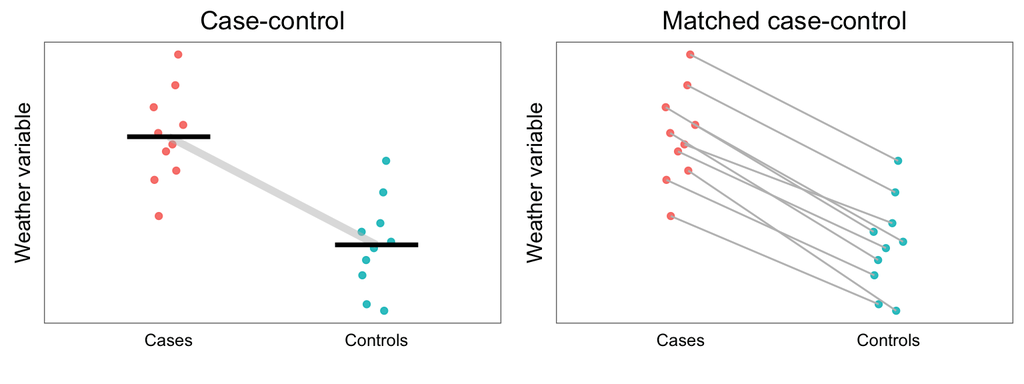

## Types of case-crossover designs

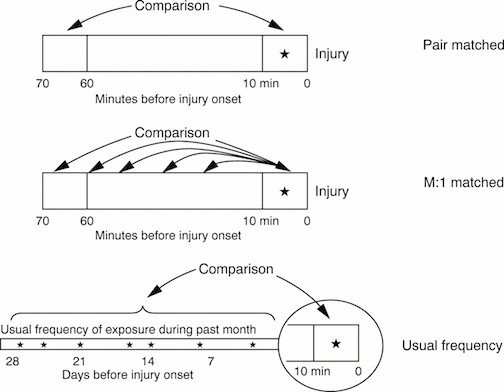

Source: Sorock et al. 2001, Injury Prevention

## Strata for case-crossover

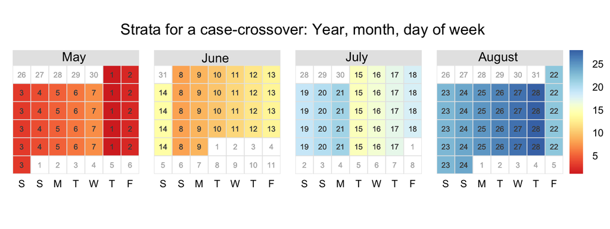

Case-crossover fit using a GLM:

\[ E(log(Y_{t})) \sim \beta_{0} + \beta_{1}PM_{t} + \beta_{2}Stratum_{t} \]

## Case-crossover

One way to fit this type of model is using a GLM, but with control by strata of year-month-day of week. To do this, first you need to create a column with the stratum. You can use `format` with the date to do this easily:

```r
chic$casecross_stratum <- format(chic$date, "%Y-%m-%a")
chic$casecross_stratum <- factor(chic$casecross_stratum)
head(chic$casecross_stratum)
```

```
## [1] 1987-01-Thu 1987-01-Fri 1987-01-Sat 1987-01-Sun 1987-01-Mon 1987-01-Tue
## 1176 Levels: 1987-01-Fri 1987-01-Mon 1987-01-Sat 1987-01-Sun ... 2000-12-Wed
```

## Case-crossover

Now you can include this factor, instead of `time` and `dow`, in your model:

```r
mod_f <- glm(cvd ~ pm10 + ns(temp, 4) + casecross_stratum,
             data = chic,
             family = quasipoisson())
summary(mod_f)$coef[c(1:2, 7:12), ]
```

```
##                                  Estimate   Std. Error    t value
## (Intercept)                  4.0482946294 0.0855215089 47.3365669
## pm10                         0.0001909843 0.0001680322  1.1365936
## casecross_stratum1987-01-Mon 0.1907876393 0.1137590495  1.6771205
## casecross_stratum1987-01-Sat 0.0855529446 0.1168756412  0.7319998
## casecross_stratum1987-01-Sun 0.3300835895 0.1099033832  3.0033979
## casecross_stratum1987-01-Thu 0.0462517003 0.1043859066  0.4430838
## casecross_stratum1987-01-Tue 0.1669288118 0.1067030371  1.5644242
## casecross_stratum1987-01-Wed 0.0729832762 0.1092532966  0.6680190
##                                 Pr(>|t|)
## (Intercept)                  0.000000000
## pm10                         0.255782198
## casecross_stratum1987-01-Mon 0.093603793
## casecross_stratum1987-01-Sat 0.464215285
## casecross_stratum1987-01-Sun 0.002687792
## casecross_stratum1987-01-Thu 0.657731180
## casecross_stratum1987-01-Tue 0.117803921
## casecross_stratum1987-01-Wed 0.504163345
```

## Case-crossover

You can interpret the coefficients now in the same way as with the time series model:

```r
pm_coef <- summary(mod_f)$coefficients["pm10", ]
100 * (exp(10 * pm_coef[1]) - 1)
```

```
##  Estimate
## 0.1911668
```

Therefore, for this model, there is a 0.191% increase in mortality for an increase of 10 \(\mu{g}/m^3\) PM10.

## Case-crossover

There are also other methods for fitting case-crossover models:

- Armstrong et al. (Conditional Poisson models: a flexible alternative to conditional logistic case cross-over analysis) suggest using a conditional Poisson regression model (`gnm()`) to speed up computational time.
- The `casecross` function in the `season` package by Adrian Barnett uses 28-day strata (rather than by month) and a Cox proportional hazards regression model to fit the model.

If you are using this method for a paper, it is worthwhile testing the different methods to see if you get similar results.

## Case-crossover

Using a conditional Poisson model:

```r
library(gnm)
mod_g <- gnm(cvd ~ pm10 + ns(temp, 4),
             eliminate = casecross_stratum,
             data = chic,
             family = quasipoisson())
pm_coef <- summary(mod_g)$coefficients["pm10", ]
100 * (exp(10 * pm_coef[1]) - 1)
```

```
##  Estimate
## 0.1911668
```

## Case-crossover

Using a Cox proportional hazards regression model:

```r
library(season)
mod_h <- casecross(cvd ~ pm10 + temp,
                   matchdow = TRUE,
                   data = chic)
```

```
## Note, irregularly spaced data...
## ...check your data for missing days
```

```r
pm_coef <- mod_h$c.model$coefficients[1]
100 * (exp(10 * pm_coef[1]) - 1)
```

```
##      pm10
## 0.4320228
```